# NBD-Part 1

## Libraries

```python
import networkx as nx
import matplotlib.pyplot as plt
from numpy import linalg as LA
import numpy as np
from scipy.sparse import csgraph
from scipy import sparse
import matplotlib.pylab as plt
from collections import defaultdict
import random

import warnings
warnings.filterwarnings('ignore')
```

## p-ER random graph.

*PSEUDOCODE*

Generating an p-ER random graph

```
01 Create an empty Graph
02 Create empty list edges
03 Add n nodes into the Graph
04 for each node source in Graph:
05 for each node target in Graph:
06 pick a random number rp from 0 to 1
07 if source!=target and (source,target) not in edges and (target,source) not in edges
08 if  rp<=probability p
09 add edge to the list and to the graph
10 endfor
11 endfor
```

```python
def erdos_renyi_graph(n_n,pp):
    '''
    Method that generates a p-ER random graph.
    input:
        n_n - number of nodes
        pp - probability that an edge is included in the graph; independently of any other edge
    output:
        generated erdos_renyi_graph
    '''
    our_graph=nx.Graph() # method that creates and empty graph from nx library
    edges=[] # list of edges
    nodes=range(0,n_n-1)
    our_graph.add_nodes_from(nodes) #adding nodes
    for source in range(n_n):
        for target in range(n_n):
            rp=random.random() # pick a random number from 0 to 1
            if source!=target and (source,target) not in edges and (target,source) not in edges: #check that source node and target node are not the same and that edge is not in edges of the graph
                if rp<=pp:#if the number is less than probability
                    edges.append((source,target))
                    our_graph.add_edge(source,target)#add that edge to the graph
    return our_graph
```

### Example of the method--> Creation of graph where n=10, p=0.3

```python
n=10
p=0.3
```

```python
G= erdos_renyi_graph(n,p)
```

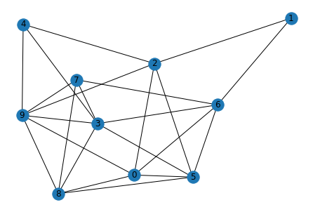

```python
nx.draw(G, with_labels=True)
plt.show()
```

## r -regular random graph.

```
  A r regular graph is a graph where each vertex has the same
  number r of neighbors.
  r regular graphs for r = 0; 1; 2 are trivial.
```

```python
#regular one
def edges_r_g(rg,r,n, node,nodes):
    '''
    Method that returns a node that with an input node will form an edge in process of generating r-regular random graph
    Input:
        rg - input Graph with all the nodes
        r -  The degree of each node that should be in the generated graph
        n -  The number of nodes
        node - input node
        nodes - list of all the nodes from the graph
    Output:
        sampled node that is in accordance with r degree constraint
    '''
    n_edges=set(rg.neighbors(node)) #set of neighbouring nodes
    if len(n_edges)<r:# if the number of neigbours is smaller than r
        req_n=1#the size of the sample is 1
    else:
        return False#"Error: r value exceeded."
    for nd in nodes:#check every node
        if len(list(rg.neighbors(nd)))>=r: #if the number of node neighbours is bigger or same as r value
            n_edges.add(nd) #store to the n_edges set
    n_edges.add(node)#add the input node in order to avoid sampling itself

    poss_nodes=list(set(nodes).difference(n_edges))#poss_nodes-possible nodes that should have more neigbours to have a 'r degree'
    if len(poss_nodes)==0:
        return False#"All nodes have r degree."

    rand_nodes=random.sample(poss_nodes,req_n)#sample req_n (sample=1); sample one node and return it
    return (rand_nodes[0])


def random_regular_graph(r,n):
    '''
    Method that generates a r-regular random graph
    input:
        r - The degree of each node
        n - The number of nodes
    output: Generated r-regular random graph
    '''
    if ((r*n)%2!=0) or (r>n): #check if the multiplication of r and n is odd or r is bigger than n
        print ("r*n is not even or r is less than n")
    else:
        rand_g=nx.Graph()#create an empty graph
        nodes=range(0,n)#create nodes
        rand_g.add_nodes_from(nodes)#add n created nodes
        for ri in range(r):#for every index ri in r
            for node in nodes:#for every node in list of all the nodes
                r_node=edges_r_g(rand_g,r,n,node,nodes)#return one of the possible nodes
                if r_node !=False:#node found
                    if len(list(rand_g.neighbors(r_node)))<r:#additional checking before adding the edge between nodes
                        rand_g.add_edge(r_node,node)
        return rand_g
```

### Example of the method--> Creation of random regular graph

```python
r_G=random_regular_graph(2,10)#2 – The degree of each node; # 10 – The number of nodes
```

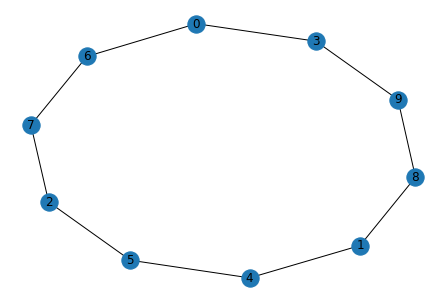

```python
nx.draw(r_G, with_labels=True)
plt.show()
```

A graph is said to be connected if there exists a path connecting any two nodes.

A graph is **connected** if one of the following statements is true

```
    -The adjacency matrix A is irreducible;
    -The second smallest eigenvalue of L is positive;
```

### Method 1 - algebraic method 1 (irreducibility)

If we consider the algebraic method 1 (**irreducibility**) a graph is **connected** if the following statement is true

```
  The adjacency matrix A is irreducible;
```

An nxn matrix A is irreducible if

$I + A + A^2 + ... + A^{n-1} > 0$ , whereby I is an identity matrix

In other words all the elements from the matrix calculated from the expression above have to be positive. If they are all positive, we can conclude that

```
    The adjacency matrix A is irreducible; Therefore, the given graph is connected.
```

```python
def irr_check(G):
    '''
    Method that checks the connectivity of the given graph by using irreducibility method of the matrix
    input: given graph
    output:
          res_matrix - matrix calculated from the formula above (for checking irreducibility on the adjacency matrix)
          irreducible - boolean value; True-Matrix is irreducible-Graph is connected; False-otherwise
    '''
    N=len(G.nodes())# N - number of nodes
    A=nx.adjacency_matrix(G).todense()# A - adjacency matrix
    res_matrix=np.identity(N,dtype=float)# res_matrix for storing the sums of identity and powered adjacency matrices
    for i in range(1,N):# beacuse we need it to N-1
        res_matrix+=np.linalg.matrix_power(A,i)
    pos_vals=sum(res_matrix>0).sum()
    no_elements=res_matrix.shape[0]**2
    res_str=''
    irreducible=True
    if pos_vals==no_elements:
        res_str='Matrix is irreducible->Graph is well connected!'
        irreducible=True
    else:
        res_str='Matrix is reducible->Graph is not well connected!'
        irreducible=False
    #print(res_str)
    return res_matrix,irreducible
```

```python
irr_check(G)[1]
```

```
True
```

### Method 2 - algebraic method 2 (eigenvalue of the Laplacian matrix)

The Laplacian matrix of a graph is an nxn matrix L defined as follows:

$L_{ii} = d_i $, where $d_i$ is the degree of node i ;

$L_{ij}= -1$ if and only if (i ; j) $\epsilon$ A.

**L = D - A**

Since the graphs in the task are undirected, L is a symmetric matrix.

##### Connectivity of a graph through algebraic method - computing eigenvalue of the Laplacian matrix

**Laplacian matrix = Kirchhoff** matrix is a matrix representation of a graph

We are going to check the connectivity of a graph through computing the second smallest eigenvalue of the Laplacian graph, **if the graph is connected, then the second smallest eigenvalue is positive.** (where the first smallest value is 0)

eigval, eigvec = sparse.linalg.eigsh(L, 10, sigma=0, which='LM') Eigval the first value - the smallest eigenvalue is zero within machine precision, and the second smallest is 1.25750986e+00

array([1.59872116e-14, 1.25750986e+00, 2.34844648e+00, 2.72152105e+00, 3.67941663e+00, 4.60614945e+00, 5.33223712e+00, 7.03749387e+00, 7.39800628e+00, 7.61921927e+00])

In order to find all the eigenvalues of matrix, we should create a characteristic polynomial of our matrix:

[output not shown]

characteristic polynomial is derived from matrix determinant, so det(L) = 0 V - eigenvalues And we put

[output not shown]

We are getting polynomial of 10 power, and computing its roots, we are getting eigenvalues. The first smallest value is 0, and the second smallest is the value we are looking for. If it's positive as in our case, then the graph is connected.

```python
D=np.identity(n)
for i in range(0,n):
    D[i,i]=G.degree(i) #Degree matrix D
```

```python
D
```

```
array([[5., 0., 0., 0., 0., 0., 0., 0., 0., 0.],
       [0., 2., 0., 0., 0., 0., 0., 0., 0., 0.],
       [0., 0., 5., 0., 0., 0., 0., 0., 0., 0.],
       [0., 0., 0., 6., 0., 0., 0., 0., 0., 0.],
       [0., 0., 0., 0., 3., 0., 0., 0., 0., 0.],
       [0., 0., 0., 0., 0., 5., 0., 0., 0., 0.],
       [0., 0., 0., 0., 0., 0., 5., 0., 0., 0.],
       [0., 0., 0., 0., 0., 0., 0., 4., 0., 0.],
       [0., 0., 0., 0., 0., 0., 0., 0., 5., 0.],
       [0., 0., 0., 0., 0., 0., 0., 0., 0., 6.]])
```

```python
def lapl_eig(G):
    '''
    Method that checks the connectivity of the given graph by using irreducibility method of the matrix
    input: given graph
    output:
          res_matrix - matrix calculated from the formula above (for checking irreducibility on the adjacency matrix)
          irreducible - boolean value; True-Matrix is irreducible-Graph is connected; False-otherwise
    '''
    n=len(G.nodes())
    D=np.identity(n)
    for i in range(0,n):
        D[i,i]=G.degree(i) #Degree matrix D
    A = nx.adjacency_matrix(G)#adjacency matrix
    L = D - A#Laplacian matrix
  #  eigval,eigvec=sparse.linalg.eigsh(L,k=2,sigma=0,which='LM')# solution to
    eigval,eigvec=sparse.linalg.eigsh(L,k=L.shape[0],sigma=0,which='LM')# solution to

    res_str=''
    connected=True
    if eigval[1]>0:
        res_str='Well connected graph!'
        connected=True
    else:
        res_str='Not connected graph'
        connected=False
  #  print(res_str)
    return eigval,eigvec,connected
```

```python
eigval,eigvec,connected=lapl_eig(G)
connected
```

```
True
```

### Method 3 - Breadth-First Search(BST) algorithm

```python
def bfs_t(G, start):
    exp=[]    #exploring nodes
    queue=[start]  #starting point

    #exploring nodes untill no nodes
    while queue:
        nd=queue.pop(0)
        if nd not in exp:
            exp.append(nd)
            nbrs=G.neighbors(nd) #getting adjacent nodes

            for nr in nbrs:
                queue.append(nr)   #take for exploring
    if (len(exp)==len(G)):
        return True
    else:
        return False
bfs_t(G,0)
```

```
True
```

### Compare the complexity as a function of n of the methods above by plotting curves of a complexity measure vs n.

```python
import time
from tqdm import tqdm
```

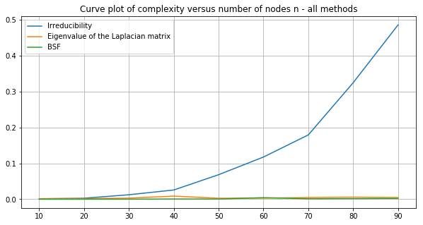

```python
# p-ER random graph.

#METHOD 1
p=0.1
complexity_dict={}
complexity_dict2={}
complexity_dict3={}

number_of_n=range(10,100,10)
for n in number_of_n:
    G=erdos_renyi_graph(n,p) #create p-ER graph
    start=time.time()
    res_matrix=irr_check(G)
    end=time.time()
    complexity_dict[n]=end-start
    start=time.time()
    eigval,eigvec,connected=lapl_eig(G)
    end=time.time()
    complexity_dict2[n]=end-start
    start=time.time()
    bfs_t(G,0)
    end=time.time()
    complexity_dict3[n]=end-start

x=complexity_dict.keys()
y=complexity_dict.values()
x2=complexity_dict2.keys()
y2=complexity_dict2.values()
x3=complexity_dict3.keys()
y3=complexity_dict3.values()

plt.figure(figsize=(10,5))
plt.plot(x, y,label='Irreducibility')
plt.plot(x2, y2,label='Eigenvalue of the Laplacian matrix')
plt.plot(x3, y3,label='BSF')

plt.title('Curve plot of complexity versus number of nodes n - all methods')
plt.legend()
plt.grid()
plt.savefig('Complexity curve plots.png')
```

```python
##### Separately shown
```

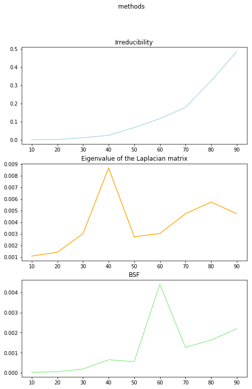

```python
fig, (ax1, ax2,ax3) = plt.subplots(3,figsize=(8,12))
fig.suptitle(' methods')
ax1.plot(x, y,color='lightblue')
ax1.set_title('Irreducibility')

ax2.plot(x2, y2,color='orange')
ax2.set_title('Eigenvalue of the Laplacian matrix')

ax3.plot(x3, y3,color='lightgreen')
ax3.set_title('BSF')
```

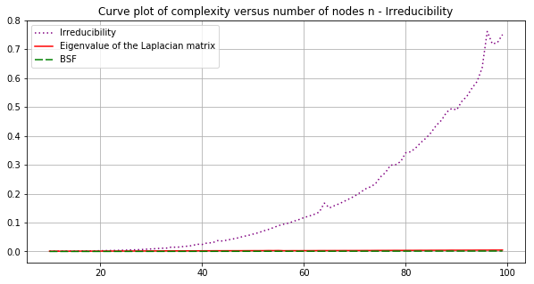

```python
# r regular random graph.

complexity_dict={}
complexity_dict2={}
complexity_dict3={}

number_of_n=range(10,100)
for n in number_of_n:
    G=random_regular_graph(10,n)
    start=time.time()
    res_matrix=irr_check(G)
    end=time.time()
    complexity_dict[n]=end-start
    start=time.time()
    eigval,eigvec,connected=lapl_eig(G)
    end=time.time()
    complexity_dict2[n]=end-start
    start=time.time()
    bfs_t(G,0)
    end=time.time()
    complexity_dict3[n]=end-start

x=complexity_dict.keys()
y=complexity_dict.values()
x2=complexity_dict2.keys()
y2=complexity_dict2.values()
x3=complexity_dict3.keys()
y3=complexity_dict3.values()

plt.figure(figsize=(10,5))
plt.plot(x, y,label='Irreducibility',color='purple',dashes=[1,2])
plt.plot(x2, y2,label='Eigenvalue of the Laplacian matrix',color='red')
plt.plot(x3, y3,label='BSF',color='green',dashes=[6, 2])
axes = plt.gca()
plt.title('Curve plot of complexity versus number of nodes n - Irreducibility')
plt.legend()
plt.grid()
```

Ranking of the connectivity checking algorithms (from best to worst):

```
1. BSF
2. Eigenvalue of the Laplacian matrix
3. Irreducibility
```

### Zoomed in to show the difference better

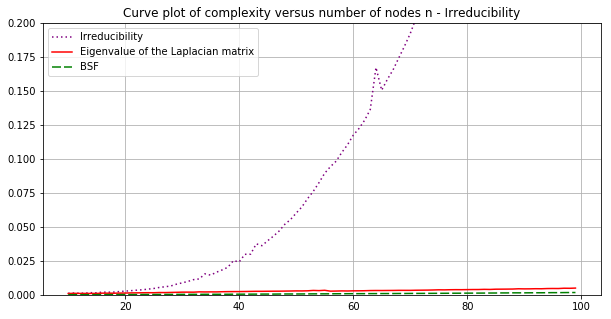

```python
plt.figure(figsize=(10,5))
plt.plot(x, y,label='Irreducibility',color='purple',dashes=[1,2])
plt.plot(x2, y2,label='Eigenvalue of the Laplacian matrix',color='red')
plt.plot(x3, y3,label='BSF',color='green',dashes=[6, 2])
axes = plt.gca()
axes.set_ylim([0,0.2])
plt.title('Curve plot of complexity versus number of nodes n - Irreducibility')
plt.legend()
plt.grid()
plt.savefig('Complexity curve plots.png')
```

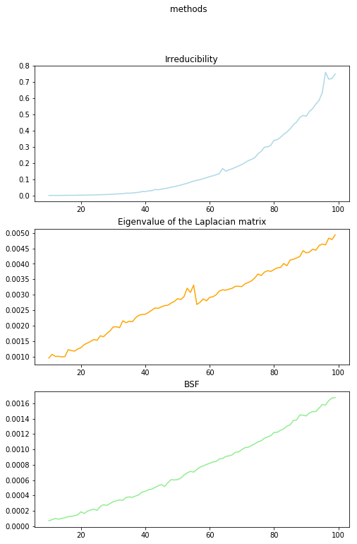

```python
fig, (ax1, ax2,ax3) = plt.subplots(3,figsize=(8,12))
fig.suptitle(' methods')
ax1.plot(x, y,color='lightblue')
ax1.set_title('Irreducibility')

ax2.plot(x2, y2,color='orange')
ax2.set_title('Eigenvalue of the Laplacian matrix')

ax3.plot(x3, y3,color='lightgreen')
ax3.set_title('BSF')
```

## 5)

Let $p_c$ (G) denote the probability that a graph G is connected. By running Monte Carlo simulations estimates pc (G) and produce two curve plots:

1. $p_c$ (G) vs. p for ER graphs with n = 100.
2. $p_c$ (G) vs. n, for n <= 100, for r-regular random graphs with r = 2 and r = 16.

### $p_c$(G) vs. p for ER graphs with n = 100.

```python
#pc (G) vs. p for Erdos-Renyi graphs with n = 100.
def our_mc(N,n_nodes,pp):
    '''
    Method that performes Monte Carlo simulation to estimate the value of probability thath Graph
    is connected
    input:
        N-number of iterations in MC simulation
        n_nodes-number of nodes
        pp-probability as input for erdos_renyi_graph method
    output:
        estimated probability based on the frequency that graph was connected by checking from
        the BFS method.
    '''

    num_of_conn=0

    for i in range(0,N):
        some_G=erdos_renyi_graph(n_nodes,pp)
        if connected==bfs_t(some_G,0):
            num_of_conn+=1
    return num_of_conn/N
```

```python
estimated=[]#list of saved estimated probabilities
p_vals=np.linspace(1/100,0.2,11)#independent variable-probability in erdos_renyi_graph
for p in p_vals:
    estimated.append(our_mc(100,100,p))
```

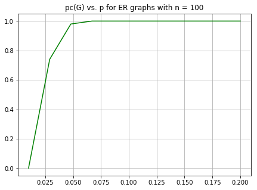

```python
title='pc(G) vs. p for ER graphs with n = 100'
plt.figure(figsize=(7,5))
plt.plot(p_vals,estimated,color='green')
plt.title(title)
plt.grid()
plt.savefig(title+'.png')
```

Based on the graph we can conclude that with the **increase of the probability**, that an edge exists, p that estimated probability pc(G) of the connectivity of the graph is **converging to 1**. More specifically it is visible from the value of p 0.05.

### $p_c$ (G) vs. n, for n <= 100, for r-regular random graphs with r = 2 and r = 16.

```python
#pc (G) vs. n, for n <= 100, for r -regular random graphs with
#r = 2 and r = 16.

def mc_reg(r1,n_mc):
    '''
    Method that performes Monte Carlo simulation to estimate the value of probability thath Graph
    is connected
    input:
        r1-degree of the nodes
        n_mc-number of iterations in MC simulation
    output:
        estimated probability based on the frequency that graph was connected by checking from
        the BFS method.
    '''
    lst_of_probs=[]#list of the estimated probabilities
    for i in range(r1+1,100):#for every value n
        num_of_r1=0#counter for connected graphs
        for j in range(0,n_mc):#for every MC iteration
            gr=random_regular_graph(r1,i)#create random_regular_graph with r1 degree of nodes
            if bfs_t(gr,0)==True:
                num_of_r1+=1#count the connected ones
        lst_of_probs.append((i,num_of_r1/n_mc))#store estimated probabilities
    return lst_of_probs
p_lst=mc_reg(2,100)#call the method for r=2
p_lst2=mc_reg(16,100)#call the method for r=16
```

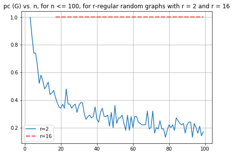

```python
title='pc (G) vs. n, for n <= 100, for r-regular random graphs with r = 2 and r = 16'
plt.figure(figsize=(7,5))
plt.plot([i[0] for i in p_lst],[i[1] for i in p_lst],label='r=2')
plt.plot([i[0] for i in p_lst2],[i[1] for i in p_lst2],label='r=16',dashes=[6, 2],color='red')
plt.title(title)
plt.legend()
plt.grid()
plt.savefig(title+'.png')
```

```
Since r is a degree of each node of the graph; it is logical that with the increase of the number of nodes with fixed value r=2 the probability that Graph is connected is decreasing.

On the other side; when r value is 16; which is a large number of neighbors for each node estimated probability is 1 since we are considering number of nodes from 17 to 100.
```